# Confident in confidence intervals?

DSCI 632: Statistics for Data Science

Peter Ralph

# $t$ distribution recap

Recall our AirBnB example:

```r
airbnb <- read.csv("../datasets/portland-airbnb-listings.csv")
airbnb$price <- as.numeric(gsub("$", "", airbnb$price, fixed=TRUE))
airbnb$instant_bookable <- (airbnb$instant_bookable == "t")
instant <- airbnb$price[airbnb$instant_bookable]
not_instant <- airbnb$price[!airbnb$instant_bookable]
(tt <- t.test(instant, not_instant))
```

```
##
##  Welch Two Sample t-test
##
## data:  instant and not_instant
## t = 3.6482, df = 5039.8, p-value = 0.0002667
## alternative hypothesis: true difference in means is not equal to 0
## 95 percent confidence interval:
##   4.475555 14.872518
## sample estimates:
## mean of x mean of y
##  124.6409  114.9668
```

## How’s the $t$ test work?

The *central limit theorem*.

## In words:

The number of *standard errors* that the *sample mean* is away from the *true mean* has a $t$ distribution.

- … with $n-1$ degrees of freedom.
- “standard error” = $s / \sqrt{n}$ = SD of the sample mean

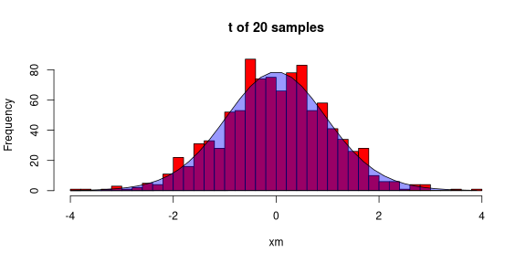

For instance, the probability that the sample mean is within 2 standard errors of the true mean [is approximately](https://en.wikipedia.org/wiki/Student%27s_t-distribution)

$$\begin{aligned}
\int_{-2}^2
\frac{\Gamma\left(\frac{n}{2}\right)}{\sqrt{(n-1)
\pi}\Gamma\left(\frac{n-1}{2}\right)}
\left(1 + \frac{x^2}{n-1}\right)^{-\frac{n}{2}} dx .
\end{aligned}$$

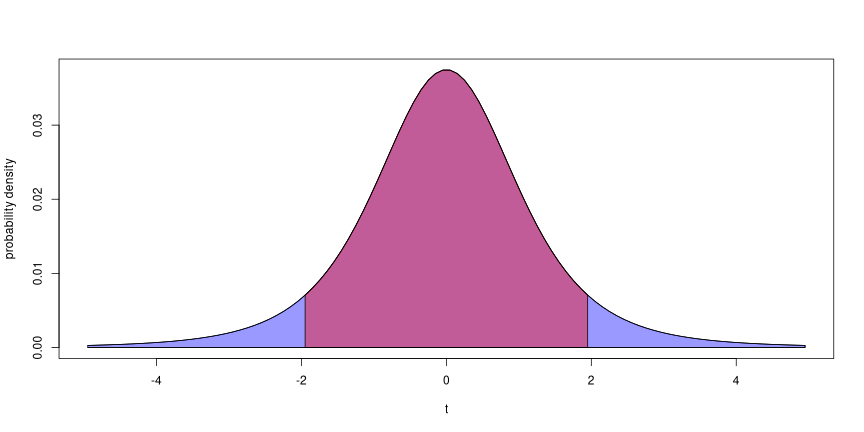

## Intuition

1. Simulate a dataset of 20 random draws from a Normal distribution with mean 0, and do a $t$ test of the hypothesis that $\mu=0$.
2. Do that 1,000 times, and make a histogram of the resulting $p$-values. What proportion are less than 0.05?
3. Change mean of the simulated values to 1, and do the same.

What’s going to happen?

# Confidence intervals

## Definition

A *95% confidence interval* for an estimate is constructed so that no matter what the true values, 95% of the the confidence intervals you construct will overlap the truth.

In other words, if we collect 100 independent samples from a source with true mean $\mu$, and construct 95% confidence intervals for the mean from each, then about 95 of these should overlap $\mu$.

## Coverage

**Definition:** the *coverage* of a procedure that produces uncertainty intervals for an estimate is the percentage of the time that the interval contains the true value.

*Notes:*

- you need to know the truth in a lot of situations to estimate the coverage
- the coverage often depends on the situation (e.g., maybe your method works better in some parts of parameter space than others)
- “uncertainty intervals” means any method that gives you ranges of values

## How’s that work?

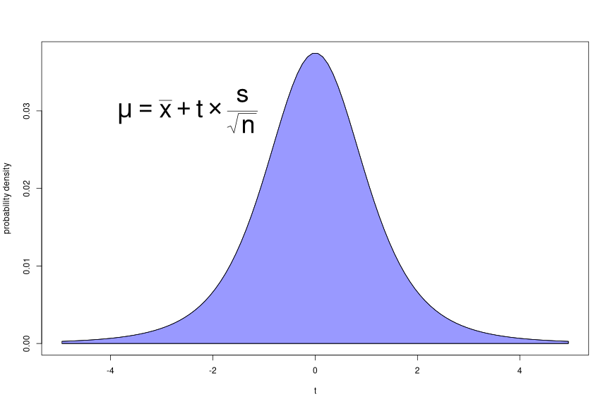

## How’s that work?

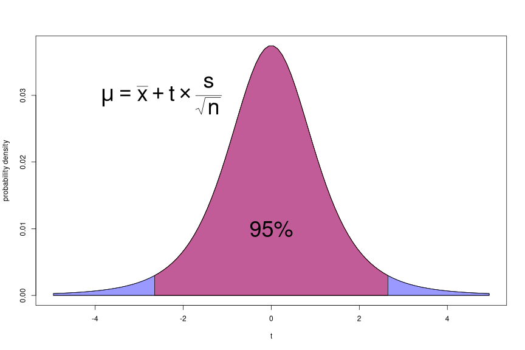

## Check this.

> if we collect 100 independent samples from a population with true mean $\mu$, and construct 95% confidence intervals for the mean from each, then about 95 of these should overlap $\mu$.

Let’s take independent samples of size $n=20$ from a Normal distribution with $\mu = 0$. Example:

```r
n <- 20; mu <- 0
t.test(rnorm(n, mean=mu))$conf.int
```

```
## [1] -0.4019083  0.5862080
## attr(,"conf.level")
## [1] 0.95
```

```r
tci <- replicate(300, t.test(rnorm(n, mean=mu))$conf.int)
mean(tci[1,] > 0 | tci[2,] < 0)
```

```
## [1] 0.05
```

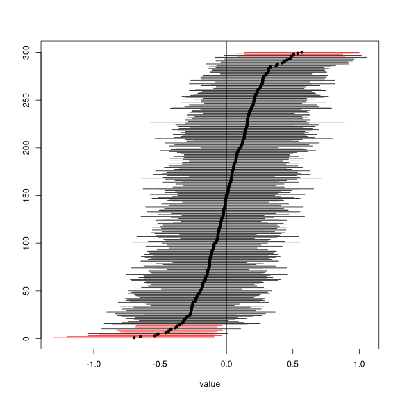

## What’s that 95% mean?

Suppose we survey 100 random UO students and find that 10 had been to a party recently and so get a 95% confidence interval of 4%-16% for the percentage of UO students who have been to a party recently.

> There is a 95% chance that the true proportion of UO students who have been to a party recently is between 4% and 16%.

This is *not quite right:* the true proportion is a *fixed* number, so it doesn’t make sense to talk about a *probability* here.

# Power analysis

**Statistical power** is how good our statistics can find things out.

Formally: the probability of identifying a true effect.

*Example:* Suppose two snail species’ speeds differ by 3cm/h on average. What’s the chance our experiment will identify the difference?

## A prospective study

Suppose that we’re going to do a survey of room prices of an AirBnB competitor. How do our power and accuracy depend on sample size? Supposing that prices roughly match AirBnB’s: mean $\mu =$ $120 and SD $\sigma =$ $98, estimate:

1. The size of the difference between the mean price of a random sample of size `n` and the (true) mean price.
2. The probability that a sample of size `n` rooms has a sample mean within $10 of the (true) mean price.

## Group exercise

Answer those questions *empirically:* by taking random samples from the `price` column of the `airbnb` data, make two plots:

1. Expected difference between the mean price of a random sample of `n` Portland AirBnB rooms and the (true) mean price of *all* rooms, as a function of `n`.
2. Probability that a sample of size `n` of Portland AirBnB rooms has a sample mean within $10 of the (true) mean price of *all* rooms, as a function of `n`.